# Homework 5 (Computational)

# 4 High-Dimension Experient (Moderately Dense)

Conduct a simulated experiment as in Problem 3 but with moderately dense data-generating coefficient vector:

$$\mathbf{\beta}=(\underbrace{1,...,1}_{1000}, \underbrace{0,...,0}_{1000})^T.$$

## 4.1 High-Dimension Experient (Moderately Dense) (I) (Total score: 15)

### 4.1.1 (a) [5 pts] Generate the above data with seed = 8910.

```r
set.seed(8910)
xtr <- matrix(rnorm(1000*2000),ncol=2000)
beta <- c(rep(1,1000),rep(0,1000))
ytr <- xtr%*%beta + rnorm(1000)
```

### 4.1.2 (b) [10 pts, 3 parts each worth 5 pts] Using `glmnet` fit Lasso, ridge regression and elastic net with $\alpha = .1,.2,.3,.4,.5,.6,.7, .8, .9$. What I am looking for: (outputting the entire model for each one of the above is not-trivial so)

#### 4.1.2.1 (b.1) Code showing the fitting of each of the above models;

```r
lasso=glmnet(xtr,ytr,alpha=1,lambda=1)
glmnet1=glmnet(xtr,ytr,alpha=0.1,lambda=1)
glmnet2=glmnet(xtr,ytr,alpha=0.2,lambda=1)
glmnet3=glmnet(xtr,ytr,alpha=0.3,lambda=1)
glmnet4=glmnet(xtr,ytr,alpha=0.4,lambda=1)
glmnet5=glmnet(xtr,ytr,alpha=0.5,lambda=1)
glmnet6=glmnet(xtr,ytr,alpha=0.6,lambda=1)
glmnet7=glmnet(xtr,ytr,alpha=0.7,lambda=1)
glmnet8=glmnet(xtr,ytr,alpha=0.8,lambda=1)
glmnet9=glmnet(xtr,ytr,alpha=0.9,lambda=1)
ridge=glmnet(xtr,ytr,alpha=0,lambda=1)
```

#### 4.1.2.2 (b.2) For ridge, Lasso and for $\alpha = .2, ,.4 ,.6$ plot the cross-validated (6 fold) MSE versus lambda as well as your optimal value of $lambda$ for ridge, Lasso and for $\alpha = .2, ,.4 ,.6$;

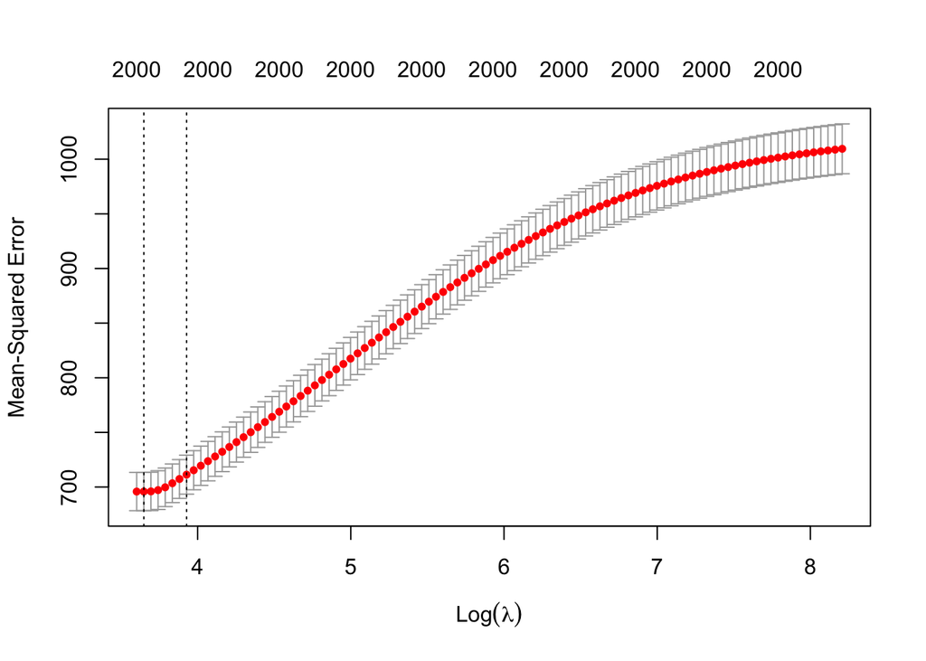

```r
cv.out1=cv.glmnet(xtr,ytr,alpha=0,nfolds=6)
plot(cv.out1)
```

```r
cat("Lambda with smallest CV Error for ridge",
cv.out1$lambda[which.min(cv.out1$cvm)],fill=TRUE)
```

```
## Lambda with smallest CV Error for ridge 38.43395
```

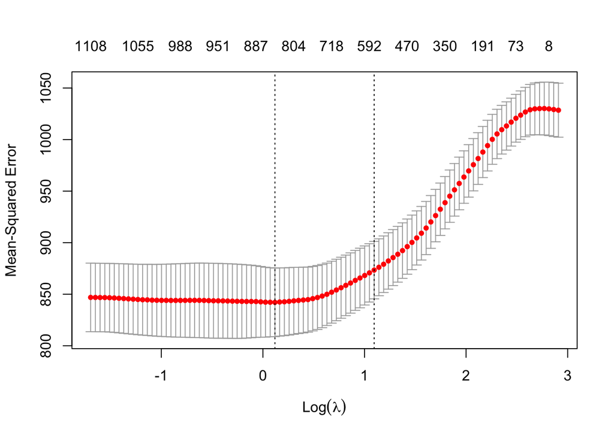

```r
cv.out2=cv.glmnet(xtr,ytr,alpha=0.2,nfolds=6)
plot(cv.out2)
```

```r
cat("Lambda with smallest CV Error for alpha=0.2 ",
cv.out2$lambda[which.min(cv.out2$cvm)],fill=TRUE)
```

```
## Lambda with smallest CV Error for alpha=0.2  1.125542
```

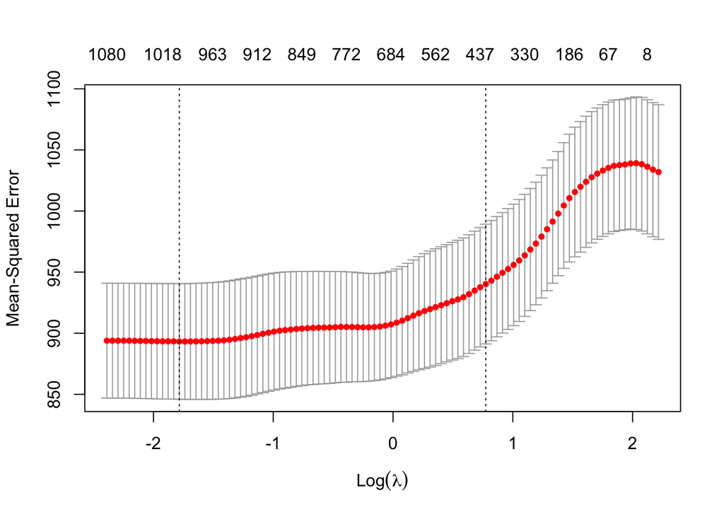

```r
cv.out3=cv.glmnet(xtr,ytr,alpha=0.4,nfolds=6)
plot(cv.out3)
```

```r
cat("Lambda with smallest CV Error for alpha=0.4",
cv.out3$lambda[which.min(cv.out3$cvm)],fill=TRUE)
```

```
## Lambda with smallest CV Error for alpha=0.4 0.1679111
```

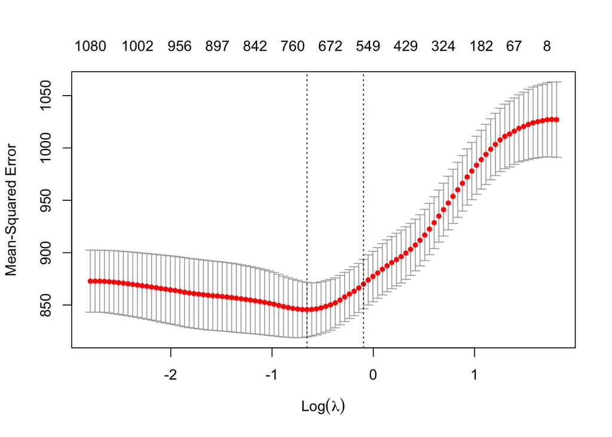

```r
cv.out4=cv.glmnet(xtr,ytr,alpha=0.6,nfolds=6)
plot(cv.out4)
```

```r
cat("Lambda with smallest CV Error for alpha=0.6",
cv.out4$lambda[which.min(cv.out4$cvm)],fill=TRUE)
```

```
## Lambda with smallest CV Error for alpha=0.6 0.5195828
```

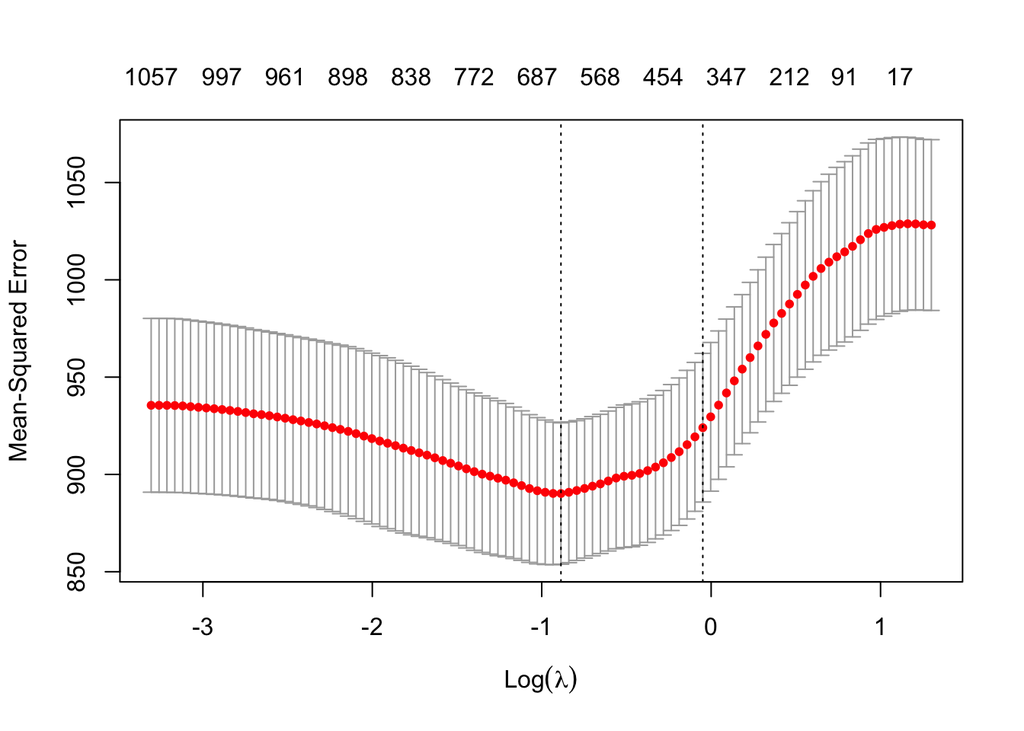

```r
cv.out5=cv.glmnet(xtr,ytr,alpha=1,nfolds=6)
plot(cv.out5)
```

```r
cat("Lambda with smallest CV Error for lasso",
cv.out5$lambda[which.min(cv.out5$cvm)],fill=TRUE)
```

```
## Lambda with smallest CV Error for lasso 0.4121147
```